# EB Statistics Practicals Guideline - Practical 1

author: Francoise Cabada-Blanco

Last updated: 20/02/2022

In this first computer lab, you will learn how to use R for descriptive statistics and provide a summary of a dataset.

The steps will be:

**1.** Create a data frame using the sizes of hedgehog stored in a csv file

**2.** Build a frequency distribution table

**3.** Plot a histogram and a boxplot

**4.** Calculate the measures of central tendency and dispersion

**5.** Report on your summary statistics

For each step you are expected to answer one or two questions. Open a new word file to copy the questions and answer them.

Before starting remember that the first thing you need to do is check that your working directory is where you intend it to be. That would be on your **Practical 1** subfolder.

## **STEP 1**

### Create a data frame using the sizes of hedgehog stored in a csv file

Samir has given you a csv (comma separated value) file with the data for the size of hedgehogs that were surveyed in his village during 2021.

You want to get that data in your Global Environment as an object of class data.frame named **hedgehogsize**. For this you click on *Import Dataset* within the *Environment* panel of RStudio (see figure 1)

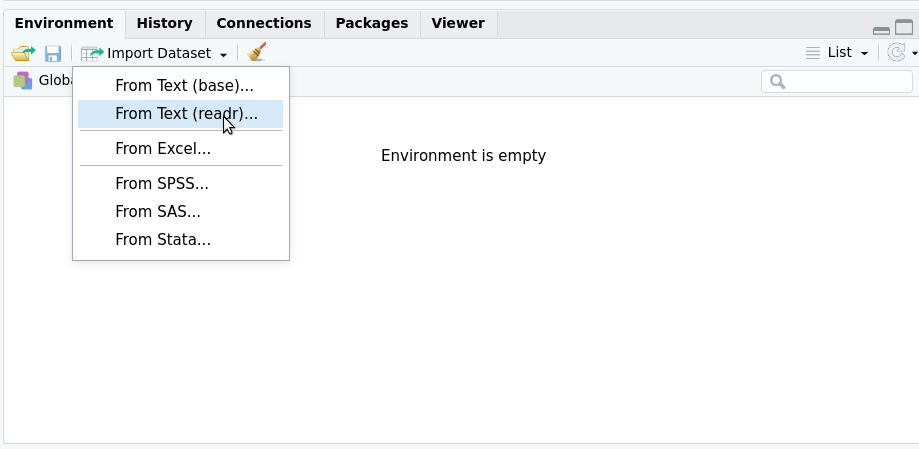

Figure 1. How to import files into the Global Environment

Once the drop-down menu displays, select *From Text (readr)* and a new window should pop-up. On the top, click the button *Browse* and navigate to the folder **Practical_1** and select the file **hedgehogSize.csv**. Once you select the file, the window should display the columns with its names, the type of data it automatically detected for each of the variables (which you can change here if you need to) and provides you with different options at the bottom left, to indicate whether or not columns have headings, etc. (see figure 2)

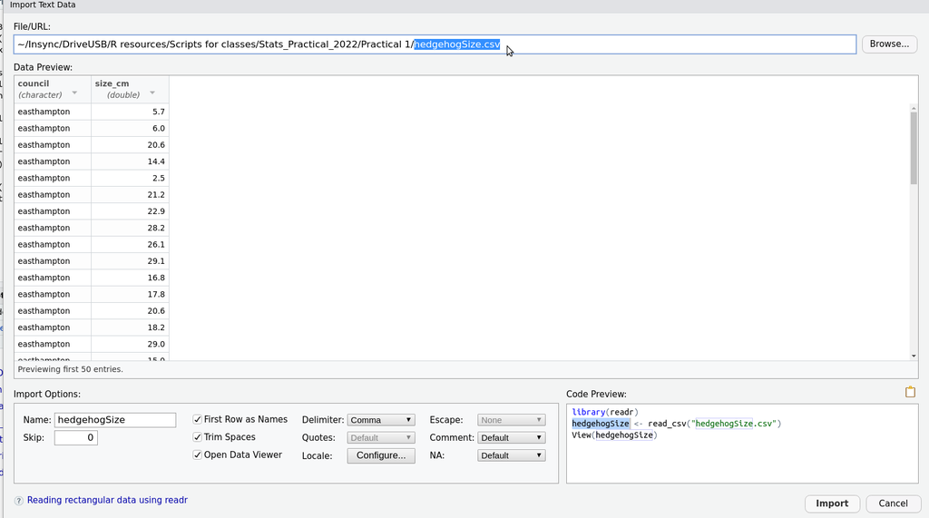

Figure 2. RStudio readr GUI

Notice that at the bottom right (figure 3) it provides the R code you would use in the console if you would like to read the file from the console. Copy and pasting these codes into your script is a good way of learning how to use R.

Copy and paste this code into your Script.

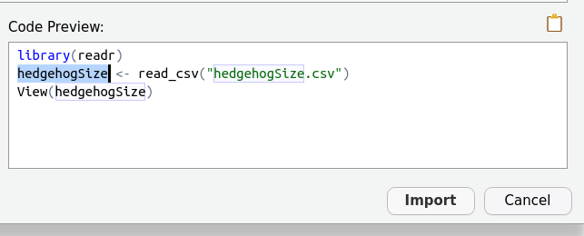

Figure 3. How to import files into the Global Environment

Click **Import**. You should see the code in the console and the dataframe in one of your RStudio panels.

You now should try to read the file by typing a command in the console.

First, click the broom icon next to *Import Dataset* within the *Environment* panel of RStudio to delete the dataframe.

The code starts by importing the library *readr*. For this, you first need to install it and then load it. Copy the following commands into your Script.

It is good practice to start all scripts with the lines that specify first, the packages that need to be installed, and then the code to load them into the session. Let us then also install and load the package *histogramTools*

Copy the code shown below into your Script and run it.

```r
################ INSTALL AND LOAD PACKAGES ###########

# Install the package

# install.packages("readr","HistogramTools")


# load the package to use it in this session
library(readr)
library(HistogramTools)
```

Now, in the code you have pasted in your Script, change the name of the dataframe from **hedgehogsize** to **hhsize**. Delete the first line where the *readr* package was loaded using the *library* function, as you have already done this. Run the commands that read your csv file creating a dataframe called **hhsize** and the one that opens the viewer. Check what class of object you have

```r
################ READING A FILE AND CHECKING THE NEW OBJECT ###########

# reading a csv file
hhsize <- read_csv("hedgehogSize.csv")

# viewing the new object
View(hhsize)

# Checking its class
class(hhsize)
```

> **Question 1**: How many cases and how many variable does the dataset has?

> **Question 1.1** : Specify the type of variable and the scale of measurement for each?

## **STEP 2**

### Build a Frequency Distribution Table

First we need to determine the width of the class intervals. Then estimate the frequency of cases on each of those interval and lastly calculate the relative frequency. Unless we have a good reason to want to use asymmetric size classes or specific ones, we can use the R function *hist* to get this information.

```r
################ BUILDING A FREQUENCY DISTRIBUTION TABLE ###########

#1 We first generate the class intervals or breaks
    ##1.2 estimate the range of values of the size_cm
max(hhsize$size_cm)-min(hhsize$size_cm)
    ##1.3 decide the number of classes.
    ## tell r to create a vector named "binNum" by creating a sequence from 0 to 36 every 4 numbers
binNum <-seq(0,36,by=4)
View(binNum)

#2 Then we generate the size classes by converting
## the hedgehog values to a factor, using the intervals or breaks  as cut points
sizeClass<-cut(hhsize$size_cm,binNum)

##3 we use the table function to count the frequencies for each class
## that is, how many values are in the size class interval or bin
## and use transform to get a vertical layout.

freq_table<-transform(table(sizeClass))
View(freq_table)

## PRACTICE: try this command without the transform function and inspect its class()
## Remember to also delete the set of parentheses corresponding to
## that function

#4 lastly, we create a data frame for our frequency distribution table by adding:
## (1) the relative frequency using the prop.table function  and (2) the cumulative frequency using ## the cumsum function (search the help to learn what exactly each of  these functions do)

groupFrequency<-transform(freq_table,Rel_freq=prop.table(Freq),Cum_Freq=cumsum(Freq))

View(groupFrequency)
```

Copy and paste the table into your Word Answer file.

Assuming the dataset of sizes is a representative sample of the population of hedgehogs in easthampton, answer:

> **Question 2**: What proportion of hedgehogs in that county would be able to pass through fence holes that are 16 cm in diameter?

Now we are going to build a second frequency table, but this time we will use a different width for the bins to reduce the number of class intervals.

```r
## tell r to create a vector named "binNum2" by creating a sequence from 0 to 36 every 9 numbers
binNum2 <-seq(0,36,by=9)
View(binNum)

#2 Then we generate the size classes by converting
## the hedgehog values to a factor, using the intervals or breaks  as cut points
sizeClass2<-cut(hhsize$size_cm,binNum2)

##3 we use the table function to count the frequencies for each class
## that is, how many values are in the size class interval or bin
## and use transform to get a vertical layout.

freq_table2<-transform(table(sizeClass2))
View(freq_table)

## PRACTICE: try this command without the transform function and inspect its class()
## Remember to also delete the set of parentheses corresponding to
## that function

#4 lastly, we create a data frame for our frequency distribution table by adding:
## (1) the relative frequency using the prop.table function  and (2) the cumulative frequency using ## the cumsum function (search the help to learn what exactly each of  these functions do)

groupFrequency2<-transform(freq_table2,Rel_freq=prop.table(Freq),Cum_Freq=cumsum(Freq))

View(groupFrequency)
```

Copy and paste the table into your Word Answer file.

## **STEP 3**

### Plot a histogram

To plot a histogram we use the function *hist*. You can learn what the function does by typing *hist* into the search box in the *Help* tab oo by typing *hist?* in the console. Below we will use the function to plot a histogram using the default settings of the function and then, we will plot another two specifying the class intervals we made above for both of our frequency tables.

```r
################ PLOT A HISTOGRAM ###########
# we create an object to save our histogram. Here we use hist1
hist1<-hist(hhsize$size_cm,
            xlab= "cm",                    # provide a label for the x axis
            main= "Hedgehog size in cm",   # provide a title for the plot
            col="green")                   # specify the colour we want the bins to have

# You have a pdf file called R color cheat sheet with the names of all colors and hues
```

Copy and paste the histogram into your Word Answer file.

```r
################ PLOT A HISTOGRAM  SPECIFYING THE BREAKS ###########

# we create an object to save our histogram. Here we use hist2
hist2<-hist(hhsize$size_cm,
            breaks = binNum,            # specify which breaks to use (same as our freq_table)
            xlab= "cm",                    # provide a label for the x axis
            main= "Hedgehog size in cm",   # provide a title for the plot
            col="blue")

# Do the same for the second class intervals width of 9.
# we create an object to save our histogram. Here we use hist3
hist3<-hist(hhsize$size_cm,
            breaks = binNum2,            # specify which breaks to use (same as our freq_table)
            xlab= "cm",                    # provide a label for the x axis
            main= "Hedgehog size in cm",   # provide a title for the plot
            col="red")
```

Copy and paste both histograms into your Word Answer file.

> **Question 3**: How would you describe the shape of the distribution of the size of hedgehogs from the first histogram?

> **Question 3.1**: How did the shape of the distribution of the size of hedgehogs changed when increasing the bin width?

If we inspect the histogram object we just created using the class intervals of our frequency table, we can see that the function *hist* outputs a list that has stored: (1) a vector named **breaks** for the bins of the histogram (2) a vector named **counts** with the simple frequency of values per bin (3) a vector named **density** with the density within each bin (4) a vector named **mids** with the mid points of the class intervals or bins (5) a character string named **xname** with the name of the variable (6) the attributes and class of the object

We can use what we learned about slicing lists in “Practical 0” to extract the density and add it to our **groupedFrequency** instead of estimating the densities for each bin ourselves

```r
################ GET THE VALUES OF DENSITY FOR EACH BIN  ###########

# slice the object hist2 as if it were a list to extract the values of density
density<-hist2$density

# add these values of density as a column or variable in our dat frame or grouped frequency
 groupFrequency<-cbind.data.frame(groupFrequency,density)

 # inspect to corroborate it worked correctly
 View(groupFrequency)

 # save or "write" the frequency table.
 write.csv(groupFrequency,file = "hedgehogSize_FreqTable.csv")
```

Check your folder to verify the file was saved. Open the file in Excel

> **Question 4:** What is the probability of sampling a hedgehog whose size is between 24 and 32 cm?

## **STEP 4**

### Calculate the measures of central tendency and dispersion

R has a built in function that provide us with the descriptive statistics we need to summarise the variables that are within a dataframe or as a vector. If we use the function *summary*, R will print in the console the most important statistics to summarise, and have an idea of the distribution of each of the variables in a dataset. Functions for each measure of location and spread are also available in R base

```r
################ GET THE SUMMARY STATISTICS  ###########

summary(hhsize)

# mean
mean(hhsize$size_cm)

# variance
var(hhsize$size_cm)

# standard deviation of the sample mean
sd(hhsize$size_cm)

# quantiles
quantile(hhsize$size_cm)
```

Copy and paste these values in your Word Answer file and arrange them in a table.

> **Question 5:** What is the value of the inter-quartile range for the size of hedgehogs?

> **Question 5.1:** What do the mean and median tell you about the distribution of the variable size?

We can now use a boxplot to illustrate how the data is distributed

```r
boxplot(hhsize$size_cm,                # specify the variable we want to plot
        main = "size of hedgehogs",    # main title
        ylab = "size in cm",           # label of y axis
        col =  "grey")                 # colour we want the box to be filled with
```

You can play with many different colours. In the pdf file named Cheat-Sheet_Rcolors.pdf within the Practical_1 folder you will find a list of the different colours you can use in R.

## PRACTICE

Using the dataset saved in the file named **seagrassCanopy.csv**, repeat the analysis routine in this practical to describe your main variable of interest. Please include:

1. A Grouped Frequency Table
2. A histogram and a Boxplot
3. Summary statistics (measures of location and spread)
4. Narrative of your results

The dataset contains data for the canopy height of a seagrass meadow, measured in 15 quadrats for each of five transects in the Langston harbour during summer 2021. The first column contains the codes for each observational unit, specifying the transect and quadrat number. The second column contains the canopy size in cm.